# Introduction to Tidyverse | using transcriptomic data

RMarkdown file to accompany the Intro to R/Tidyverse workshop (using processed transcriptomic data)

Janani Ravi https://jravilab.github.io (DBMI, CU Anschutz, R-Ladies Aurora)https://github.com/rladies-aurora , Arjun Krishnan https://thekrishnanlab.org (DBMI, CU Anschutz)https://medschool.cuanschutz.edu/dbmi  
2025-03-11

### About Janani

Janani is a computational biologist, an Asst. Professor in the departments of Biomedical Informatics, CU Anschutz In her group, they develop computational approaches to understand infectious disease biology. Check out her [webpage](https://jravilab.github.io) for more info. You can reach her [here](https://jravilab.github.io/#contact).

She’s also the founder & co-organizer of the [R-Ladies Aurora](https://www.meetup.com/rladies-aurora/), [R-Ladies East Lansing](https://rladies-eastlansing.github.io), Women+ Data Science, and AsiaR. They conduct R and data science related meetups & workshops regularly! So, do check out our upcoming events on [Meetup](https://www.meetup.com/rladies-aurora/events/).

# Part 1: Getting Started w/ `readr`

You can access all relevant material pertaining to this workshop [here](https://github.com/rladies-aurora/202503-RIntro-DataWrangling-Transcriptomics). Other related workshops & useful cheatsheets.

## Installation and set-up

### Install RStudio

*Running RStudio locally?* [**Download RStudio**](http://rstudio.com/download)

*Want to try the latest ‘Preview’ version of RStudio?* **RStudio Preview version**

*Trouble with local installation?* Login & start using [**RStudio Cloud**](https://rstudio.cloud) right away!

*New to RStudio IDE?* Use Help [Page #1](https://www.rstudio.com/products/rstudio/#Desktop) & [Page #2](https://www.rstudio.com/products/rstudio/features/)

### Install R

*… if you haven’t already!* The RStudio startup message should specify your current local version of R. For *e.g.,* `R v4.1.2`

- [Download R](https://cran.r-project.org)
- [*Update to the latest version of R?*](https://www.linkedin.com/pulse/3-methods-update-r-rstudio-windows-mac-woratana-ngarmtrakulchol)
- [A Windows-specific solution to updating R](https://www.r-statistics.com/2015/06/a-step-by-step-screenshots-tutorial-for-upgrading-r-on-windows/)

### Install packages

- **Install**: once
- **Load**: each time

```r
install.packages("tidyverse")   # for data wrangling
install.packages("here")        # to set paths relative to your current project.
# install.packages("gapminder") # sample dataset
```

Explore the [RLEL workshops](https://github.com/rladies-eastlansing/meetup-presentations) for more examples and sample codes for Tidy Data and DataViz [*e.g.,* >> `presentations/20181105-workshop-tidydata` uses the `gapminder` & `USArrests` datasets].

**Trouble installing tidyverse?**

- Check your R/RStudio versions
- For the time-being install the individual packages using `install.packages("PACKAGENAME")`
- Check out the whole `tidyverse` suite of packages [here](https://www.tidyverse.org/packages/)

```r
# If tidyverse installation fails, install individual constituent packages this way...
install.packages("readr")    # Importing data files
install.packages("tidyr")    # Tidy Data
install.packages("dplyr")    # Data manipulation
install.packages("ggplot2")  # Data Visualization (w/ Grammar of Graphics)
install.packages("readxl")   # Importing excel files
```

### Loading packages

```r
library(tidyverse)
```

```r
# OR load the individual packages, if you have trouble installing/loading `tidyverse`
# library(readr)
# library(readxl)
# library(tidyr)
# library(dplyr)
# library(ggplot2)
library(here) # https://github.com/jennybc/here_here
# library(gapminder) # useful dataset for data wrangling, visualization
```

## Some useful cheatsheets

[Cheatsheets @RStudio](https://www.rstudio.com/resources/cheatsheets/) | [Our cheatsheets repo](https://github.com/rladies-aurora/cheatsheets)

More resources towards the end of the document.

## Data import

- `read_csv`, `write_csv`
- `read_tsv`, `write_tsv`
- `read_delim`, `write_delim`
- `here::here`

```r
here::here() # where you opened your RStudio session/Project
```

```
[1] "/Users/kewalinsamart/Documents/GitHub/202503-RIntro-DataWrangling-Transcriptomics"
```

```r
# Downloading sample transcriptomics dataset from NCBI's FTP site
url <- "ftp://ftp.ncbi.nlm.nih.gov/geo/series/GSE69nnn/GSE69360/suppl/GSE69360_RNAseq.counts.txt.gz"
gse69360 <- read_tsv(url) # to read tab-delimitted files
?read_tsv # to check defaults
```

```r
# Comma-separated values, as exported from excel/spreadsheets
read_csv(file="path/to/my_data.csv", col_names=T)
# Other atypical delimitters
read_delim(file="path/to/my_data.txt", col_names=T, delim="//")

# Other useful packages
# readxl by Jenny Bryan
read_excel(path="path/to/excel.xls",
           sheet=1,
           range="A1:D50",
           col_names=T)

## Tip: Always open .Rproj and use relative paths with here()
## Example with here()
read_tsv(file=here("transcriptomics/GSE69360_RNAseq.counts.txt"), col_names=T)
```

## Knowing your data

*Dataset details*:

- AA: Agilent Adult; AF: Agilent Fetus
- BA: BioChain Adult; BF: BioChain Fetus
- OA: OriGene Adult
- Tissues: Colon, Heart, Kidney, Liver, Lung, Stomach

```r
str(gse69360)              # Structure of the dataframe
gse69360                   # Data is in a cleaned up 'tibble' format by default
head(gse69360)             # Shows the top few observations (rows) of your dataframe
glimpse(gse69360)          # Info-dense summary of the data
View(head(gse69360, 100))  # View data in a visual GUI-based spreadsheet-like format

colnames(gse69360)         # Column names
nrow(gse69360)             # No. of rows
ncol(gse69360)             # No. of columns

gse69360[1:5,7:10]         # Subsetting a dataframe

## saving the data file
write_tsv(gse69360[1:100,7:12], "gse_subset.txt")
```

```r
library(knitr)
kable(head(gse69360))
```

| Geneid | Chr | Start | End | Strand | Length | AA_Colon | AA_Heart | AA_Kidney | AA_Liver | AA_Lung | AA_Stomach | AF_Colon | AF_Stomach | BA_Colon | BA_Heart | BA_Kidney | BA_Liver | BA_Lung | BA_Stomach | BF_Colon | BF_Stomach | OA_Stomach1 | OA_Stomach2 | OA_Stomach3 |
| --- | --- | --- | --- | --- | --- | --- | --- | --- | --- | --- | --- | --- | --- | --- | --- | --- | --- | --- | --- | --- | --- | --- | --- | --- |
| ENSG00000223972.4 | chr1;chr1;chr1;chr1 | 11869;12595;12975;13221 | 12227;12721;13052;14412 | +;+;+;+ | 1756 | 1 | 0 | 0 | 0 | 0 | 0 | 7 | 2 | 0 | 0 | 0 | 0 | 7 | 0 | 0 | 3 | 3 | 1 | 0 |
| ENSG00000227232.4 | chr1;chr1;chr1;chr1;chr1;chr1;chr1;chr1;chr1;chr1;chr1;chr1;chr1 | 14363;14970;15796;16607;16854;17233;17498;17602;17915;18268;24734;29321;29534 | 14829;15038;15947;16765;17055;17368;17504;17742;18061;18379;24891;29370;29806 | -;-;-;-;-;-;-;-;-;-;-;-;- | 2073 | 36 | 21 | 32 | 28 | 17 | 17 | 102 | 41 | 10 | 24 | 22 | 6 | 49 | 2 | 153 | 157 | 38 | 53 | 18 |
| ENSG00000243485.2 | chr1;chr1;chr1 | 29554;30267;30976 | 30039;30667;31109 | +;+;+ | 1021 | 0 | 0 | 0 | 0 | 0 | 0 | 0 | 0 | 0 | 0 | 0 | 0 | 0 | 0 | 0 | 0 | 0 | 0 | 0 |
| ENSG00000237613.2 | chr1;chr1;chr1 | 34554;35245;35721 | 35174;35481;36081 | -;-;- | 1219 | 0 | 0 | 0 | 0 | 0 | 0 | 0 | 0 | 0 | 0 | 0 | 0 | 0 | 0 | 0 | 0 | 0 | 0 | 0 |
| ENSG00000268020.2 | chr1;chr1 | 52473;54830 | 53312;54936 | +;+ | 947 | 0 | 0 | 0 | 0 | 0 | 0 | 0 | 0 | 0 | 0 | 0 | 0 | 4 | 0 | 0 | 0 | 0 | 0 | 0 |
| ENSG00000240361.1 | chr1 | 62948 | 63887 | + | 940 | 0 | 0 | 0 | 0 | 0 | 0 | 0 | 0 | 0 | 0 | 0 | 0 | 0 | 0 | 0 | 0 | 0 | 0 | 0 |

```r
library(rmarkdown)
paged_table(gse69360)
```

| Geneid | Chr | Start | End | Strand | Length | AA_Colon | AA_Heart | AA_Kidney | AA_Liver | AA_Lung | AA_Stomach | AF_Colon | AF_Stomach | BA_Colon | BA_Heart | BA_Kidney | BA_Liver | BA_Lung | BA_Stomach | BF_Colon | BF_Stomach | OA_Stomach1 | OA_Stomach2 | OA_Stomach3 |
| --- | --- | --- | --- | --- | --- | --- | --- | --- | --- | --- | --- | --- | --- | --- | --- | --- | --- | --- | --- | --- | --- | --- | --- | --- |
| ENSG00000223972.4 | chr1;chr1;chr1;chr1 | 11869;12595;12975;13221 | 12227;12721;13052;14412 | +;+;+;+ | 1756 | 1 | 0 | 0 | 0 | 0 | 0 | 7 | 2 | 0 | 0 | 0 | 0 | 7 | 0 | 0 | 3 | 3 | 1 | 0 |
| ENSG00000227232.4 | chr1;chr1;chr1;chr1;chr1;chr1;chr1;chr1;chr1;chr1;chr1;chr1;chr1 | 14363;14970;15796;16607;16854;17233;17498;17602;17915;18268;24734;29321;29534 | 14829;15038;15947;16765;17055;17368;17504;17742;18061;18379;24891;29370;29806 | -;-;-;-;-;-;-;-;-;-;-;-;- | 2073 | 36 | 21 | 32 | 28 | 17 | 17 | 102 | 41 | 10 | 24 | 22 | 6 | 49 | 2 | 153 | 157 | 38 | 53 | 18 |
| ENSG00000243485.2 | chr1;chr1;chr1 | 29554;30267;30976 | 30039;30667;31109 | +;+;+ | 1021 | 0 | 0 | 0 | 0 | 0 | 0 | 0 | 0 | 0 | 0 | 0 | 0 | 0 | 0 | 0 | 0 | 0 | 0 | 0 |
| ENSG00000237613.2 | chr1;chr1;chr1 | 34554;35245;35721 | 35174;35481;36081 | -;-;- | 1219 | 0 | 0 | 0 | 0 | 0 | 0 | 0 | 0 | 0 | 0 | 0 | 0 | 0 | 0 | 0 | 0 | 0 | 0 | 0 |
| ENSG00000268020.2 | chr1;chr1 | 52473;54830 | 53312;54936 | +;+ | 947 | 0 | 0 | 0 | 0 | 0 | 0 | 0 | 0 | 0 | 0 | 0 | 0 | 4 | 0 | 0 | 0 | 0 | 0 | 0 |
| ENSG00000240361.1 | chr1 | 62948 | 63887 | + | 940 | 0 | 0 | 0 | 0 | 0 | 0 | 0 | 0 | 0 | 0 | 0 | 0 | 0 | 0 | 0 | 0 | 0 | 0 | 0 |
| ENSG00000186092.4 | chr1 | 69091 | 70008 | + | 918 | 0 | 0 | 0 | 0 | 0 | 0 | 0 | 0 | 0 | 0 | 0 | 0 | 0 | 0 | 0 | 0 | 0 | 0 | 0 |
| ENSG00000238009.2 | chr1;chr1;chr1;chr1;chr1;chr1;chr1 | 89295;92091;110953;112700;120721;129055;133374 | 91629;92240;111357;112804;120932;129223;133566 | -;-;-;-;-;-;- | 3569 | 3 | 0 | 1 | 2 | 1 | 0 | 4 | 0 | 0 | 1 | 0 | 0 | 5 | 0 | 5 | 4 | 1 | 2 | 1 |
| ENSG00000239945.1 | chr1;chr1 | 89551;90287 | 90050;91105 | -;- | 1319 | 0 | 0 | 0 | 0 | 0 | 0 | 0 | 0 | 0 | 0 | 0 | 0 | 0 | 0 | 0 | 0 | 0 | 0 | 0 |
| ENSG00000233750.3 | chr1 | 131025 | 134836 | + | 3812 | 0 | 0 | 0 | 0 | 0 | 1 | 2 | 3 | 0 | 0 | 1 | 0 | 6 | 0 | 3 | 1 | 1 | 0 | 2 |

[output cut: 9990 more lines]

# Part 2: Reshaping data w/ `tidyr`

```r
## legacy tidyverse functions
gather()   # Gather COLUMNS -> ROWS
spread()   # Spread ROWS -> COLUMNS

## newer tidyverse functions
pivot_longer()  # Pivot data from wide to long
pivot_wider()   # Pivot data from long to wide

separate() # Separate 1 COLUMN -> many COLUMNS
unite()    # Unite several COLUMNS -> 1 COLUMN
```

## Gather, Spread

- `gather`: *Gather columns into key-value pairs. Wide -> Long*
- `spread`: *Spread a key-value pair across multiple columns: Long -> Wide*

```r
# Gather all columns except 'Geneid'
gse69360 %>%
  select(Geneid, matches("[AF]_")) %>%
  # gather(-Geneid, key="Sample", value="Counts") # wide -> long format  ## legacy
  pivot_longer(cols=matches("[AF]_"), names_to="Sample", values_to="Counts")
```

```
# A tibble: 1,098,580 × 3
   Geneid            Sample     Counts
   <chr>             <chr>       <dbl>
 1 ENSG00000223972.4 AA_Colon        1
 2 ENSG00000223972.4 AA_Heart        0
 3 ENSG00000223972.4 AA_Kidney       0
 4 ENSG00000223972.4 AA_Liver        0
 5 ENSG00000223972.4 AA_Lung         0
 6 ENSG00000223972.4 AA_Stomach      0
 7 ENSG00000223972.4 AF_Colon        7
 8 ENSG00000223972.4 AF_Stomach      2
 9 ENSG00000223972.4 BA_Colon        0
10 ENSG00000223972.4 BA_Heart        0
# ℹ 1,098,570 more rows
```

```r
# Gather, then Spread --> Back to original data
gse69360 %>%
  select(Geneid, matches("[AF]_")) %>%
  # gather(-Geneid, key="Sample", value="Counts") %>%
  # spread(key = "Sample", value = "Counts")     # spread to turn back to the original data!
  pivot_longer(cols=matches("[AF]_"), names_to="Sample", values_to="Counts") %>%
  pivot_wider(names_from="Sample", values_from="Counts")
```

```
# A tibble: 57,820 × 20
   Geneid       AA_Colon AA_Heart AA_Kidney AA_Liver AA_Lung
   <chr>           <dbl>    <dbl>     <dbl>    <dbl>   <dbl>
 1 ENSG0000022…        1        0         0        0       0
 2 ENSG0000022…       36       21        32       28      17
 3 ENSG0000024…        0        0         0        0       0
 4 ENSG0000023…        0        0         0        0       0
 5 ENSG0000026…        0        0         0        0       0
 6 ENSG0000024…        0        0         0        0       0
 7 ENSG0000018…        0        0         0        0       0
 8 ENSG0000023…        3        0         1        2       1
 9 ENSG0000023…        0        0         0        0       0
10 ENSG0000023…        0        0         0        0       0
# ℹ 57,810 more rows
# ℹ 14 more variables: AA_Stomach <dbl>, AF_Colon <dbl>,
#   AF_Stomach <dbl>, BA_Colon <dbl>, BA_Heart <dbl>,
#   BA_Kidney <dbl>, BA_Liver <dbl>, BA_Lung <dbl>,
#   BA_Stomach <dbl>, BF_Colon <dbl>, BF_Stomach <dbl>,
#   OA_Stomach1 <dbl>, OA_Stomach2 <dbl>, OA_Stomach3 <dbl>
```

## Unite, Separate

- `unite`: *Unite multiple columns into one*
- `separate`: *Separate one column into multiple columns*

```r
gse69360 %>%
  select(Geneid, matches("[AF]_")) %>%               # selecting only Counts columns
  pivot_longer(cols=matches("[AF]_"), names_to="Sample", values_to="Counts") %>% # wide -> long
  separate(Sample, into=c("Source_Stage", "Tissue"), sep="_") # separate logically
```

```
# A tibble: 1,098,580 × 4
   Geneid            Source_Stage Tissue  Counts
   <chr>             <chr>        <chr>    <dbl>
 1 ENSG00000223972.4 AA           Colon        1
 2 ENSG00000223972.4 AA           Heart        0
 3 ENSG00000223972.4 AA           Kidney       0
 4 ENSG00000223972.4 AA           Liver        0
 5 ENSG00000223972.4 AA           Lung         0
 6 ENSG00000223972.4 AA           Stomach      0
 7 ENSG00000223972.4 AF           Colon        7
 8 ENSG00000223972.4 AF           Stomach      2
 9 ENSG00000223972.4 BA           Colon        0
10 ENSG00000223972.4 BA           Heart        0
# ℹ 1,098,570 more rows
```

```r
gse69360 %>%
  select(Geneid, matches("[AF]_")) %>%
  pivot_longer(cols=matches("[AF]_"), names_to="Sample", values_to="Counts") %>%
  separate(Sample, into=c("Source_Stage", "Tissue"), sep="_") %>%
  separate(Source_Stage, into=c("Source", "Stage"), sep=1) # separate by char position
```

```
# A tibble: 1,098,580 × 5
   Geneid            Source Stage Tissue  Counts
   <chr>             <chr>  <chr> <chr>    <dbl>
 1 ENSG00000223972.4 A      A     Colon        1
 2 ENSG00000223972.4 A      A     Heart        0
 3 ENSG00000223972.4 A      A     Kidney       0
 4 ENSG00000223972.4 A      A     Liver        0
 5 ENSG00000223972.4 A      A     Lung         0
 6 ENSG00000223972.4 A      A     Stomach      0
 7 ENSG00000223972.4 A      F     Colon        7
 8 ENSG00000223972.4 A      F     Stomach      2
 9 ENSG00000223972.4 B      A     Colon        0
10 ENSG00000223972.4 B      A     Heart        0
# ℹ 1,098,570 more rows
```

```r
gse69360 %>%
  select(Geneid, matches("[AF]_")) %>%
  pivot_longer(cols=matches("[AF]_"), names_to="Sample", values_to="Counts") %>%
  separate(Sample, into=c("Source_Stage", "Tissue"), sep="_") %>%
  separate(Source_Stage, into=c("Source", "Stage"), sep=1) %>%
  unite(Stage_Tissue, Stage, Tissue) # combining a different set of columns
```

```
# A tibble: 1,098,580 × 4
   Geneid            Source Stage_Tissue Counts
   <chr>             <chr>  <chr>         <dbl>
 1 ENSG00000223972.4 A      A_Colon           1
 2 ENSG00000223972.4 A      A_Heart           0
 3 ENSG00000223972.4 A      A_Kidney          0
 4 ENSG00000223972.4 A      A_Liver           0
 5 ENSG00000223972.4 A      A_Lung            0
 6 ENSG00000223972.4 A      A_Stomach         0
 7 ENSG00000223972.4 A      F_Colon           7
 8 ENSG00000223972.4 A      F_Stomach         2
 9 ENSG00000223972.4 B      A_Colon           0
10 ENSG00000223972.4 B      A_Heart           0
# ℹ 1,098,570 more rows
```

# Part 3: Data wranging with `dplyr`

```r
conflicted::conflict_prefer(name="filter", winner="dplyr")
filter()    # PICK observations by their values | ROWS
select()    # PICK variables by their names | COLUMNS
mutate()    # CREATE new variables w/ functions of existing variables | COLUMNS
transmute() # COMPUTE 1 or more COLUMNS but drop original columns
arrange()   # REORDER the ROWS
summarize() # COLLAPSE many values to a single SUMMARY
group_by()  # GROUP data into rows with the same value of variable (COLUMN)
```

## Filter

- `filter`: *Return rows with matching conditions*

```r
head(gse69360) # Snapshot of the dataframe
```

```
# A tibble: 6 × 25
  Geneid   Chr   Start End   Strand Length AA_Colon AA_Heart
  <chr>    <chr> <chr> <chr> <chr>   <dbl>    <dbl>    <dbl>
1 ENSG000… chr1… 1186… 1222… +;+;+…   1756        1        0
2 ENSG000… chr1… 1436… 1482… -;-;-…   2073       36       21
3 ENSG000… chr1… 2955… 3003… +;+;+    1021        0        0
4 ENSG000… chr1… 3455… 3517… -;-;-    1219        0        0
5 ENSG000… chr1… 5247… 5331… +;+       947        0        0
6 ENSG000… chr1  62948 63887 +         940        0        0
# ℹ 17 more variables: AA_Kidney <dbl>, AA_Liver <dbl>,
#   AA_Lung <dbl>, AA_Stomach <dbl>, AF_Colon <dbl>,
#   AF_Stomach <dbl>, BA_Colon <dbl>, BA_Heart <dbl>,
#   BA_Kidney <dbl>, BA_Liver <dbl>, BA_Lung <dbl>,
#   BA_Stomach <dbl>, BF_Colon <dbl>, BF_Stomach <dbl>,
#   OA_Stomach1 <dbl>, OA_Stomach2 <dbl>, OA_Stomach3 <dbl>
```

```r
# Now, filter by condition
filter(gse69360, Length<=50)
```

```
# A tibble: 124 × 25
   Geneid  Chr   Start End   Strand Length AA_Colon AA_Heart
   <chr>   <chr> <chr> <chr> <chr>   <dbl>    <dbl>    <dbl>
 1 ENSG00… chr1… 3829… 3829… -;-        45        1        0
 2 ENSG00… chr1  9521… 9521… -          41        7        1
 3 ENSG00… chr1  1477… 1477… +          35        0        1
 4 ENSG00… chr1… 1545… 1545… +;+        21        0        0
 5 ENSG00… chr1  2360… 2360… -          50        1        2
 6 ENSG00… chr2… 1160… 1160… +;+        36        1        0
 7 ENSG00… chr2  8916… 8916… -          38      183        1
 8 ENSG00… chr2  8916… 8916… -          37       98        2
 9 ENSG00… chr2  8916… 8916… -          38       80        0
10 ENSG00… chr2  8916… 8916… -          38        0        0
# ℹ 114 more rows
# ℹ 17 more variables: AA_Kidney <dbl>, AA_Liver <dbl>,
#   AA_Lung <dbl>, AA_Stomach <dbl>, AF_Colon <dbl>,
#   AF_Stomach <dbl>, BA_Colon <dbl>, BA_Heart <dbl>,
#   BA_Kidney <dbl>, BA_Liver <dbl>, BA_Lung <dbl>,
#   BA_Stomach <dbl>, BF_Colon <dbl>, BF_Stomach <dbl>,
#   OA_Stomach1 <dbl>, OA_Stomach2 <dbl>, …
```

```r
# Can be rewritten using "Piping" %>%
gse69360 %>%   # Pipe ('then') operator to serially connect operations
  filter(Length <= 50)
```

```
# A tibble: 124 × 25
   Geneid  Chr   Start End   Strand Length AA_Colon AA_Heart
   <chr>   <chr> <chr> <chr> <chr>   <dbl>    <dbl>    <dbl>
 1 ENSG00… chr1… 3829… 3829… -;-        45        1        0
 2 ENSG00… chr1  9521… 9521… -          41        7        1
 3 ENSG00… chr1  1477… 1477… +          35        0        1
 4 ENSG00… chr1… 1545… 1545… +;+        21        0        0
 5 ENSG00… chr1  2360… 2360… -          50        1        2
 6 ENSG00… chr2… 1160… 1160… +;+        36        1        0
 7 ENSG00… chr2  8916… 8916… -          38      183        1
 8 ENSG00… chr2  8916… 8916… -          37       98        2
 9 ENSG00… chr2  8916… 8916… -          38       80        0
10 ENSG00… chr2  8916… 8916… -          38        0        0
# ℹ 114 more rows
# ℹ 17 more variables: AA_Kidney <dbl>, AA_Liver <dbl>,
#   AA_Lung <dbl>, AA_Stomach <dbl>, AF_Colon <dbl>,
#   AF_Stomach <dbl>, BA_Colon <dbl>, BA_Heart <dbl>,
#   BA_Kidney <dbl>, BA_Liver <dbl>, BA_Lung <dbl>,
#   BA_Stomach <dbl>, BF_Colon <dbl>, BF_Stomach <dbl>,
#   OA_Stomach1 <dbl>, OA_Stomach2 <dbl>, …
```

```r
# Filtering using regex/substring match
gse69360 %>%
  filter(grepl("chrY", Chr))
```

```
# A tibble: 542 × 25
   Geneid  Chr   Start End   Strand Length AA_Colon AA_Heart
   <chr>   <chr> <chr> <chr> <chr>   <dbl>    <dbl>    <dbl>
 1 ENSGR0… chrY… 1204… 1205… +;+       259        0        0
 2 ENSGR0… chrY… 1429… 1430… +;+;+…   6191        0        0
 3 ENSGR0… chrY… 1700… 1701… -;-;-…   2363        0        0
 4 ENSGR0… chrY… 2317… 2319… +;+       428        0        0
 5 ENSGR0… chrY… 2446… 2496… -;-;-…   9015        0        0
 6 ENSGR0… chrY  3753… 3754… -         101        0        0
 7 ENSGR0… chrY  4345… 4348… -         328        0        0
 8 ENSGR0… chrY  4559… 4560… -         117        0        0
 9 ENSGR0… chrY… 5350… 5353… +;+;+…   4384        0        0
10 ENSGR0… chrY… 9009… 9011… +;+       588        0        0
# ℹ 532 more rows
# ℹ 17 more variables: AA_Kidney <dbl>, AA_Liver <dbl>,
#   AA_Lung <dbl>, AA_Stomach <dbl>, AF_Colon <dbl>,
#   AF_Stomach <dbl>, BA_Colon <dbl>, BA_Heart <dbl>,
#   BA_Kidney <dbl>, BA_Liver <dbl>, BA_Lung <dbl>,
#   BA_Stomach <dbl>, BF_Colon <dbl>, BF_Stomach <dbl>,
#   OA_Stomach1 <dbl>, OA_Stomach2 <dbl>, …
```

```r
# Two filters at a time
gse69360 %>%
  filter(Length <= 50 & grepl("chrY", Chr))
```

```
# A tibble: 1 × 25
  Geneid   Chr   Start End   Strand Length AA_Colon AA_Heart
  <chr>    <chr> <chr> <chr> <chr>   <dbl>    <dbl>    <dbl>
1 ENSG000… chrY… 5306… 5306… -;-        42        1        0
# ℹ 17 more variables: AA_Kidney <dbl>, AA_Liver <dbl>,
#   AA_Lung <dbl>, AA_Stomach <dbl>, AF_Colon <dbl>,
#   AF_Stomach <dbl>, BA_Colon <dbl>, BA_Heart <dbl>,
#   BA_Kidney <dbl>, BA_Liver <dbl>, BA_Lung <dbl>,
#   BA_Stomach <dbl>, BF_Colon <dbl>, BF_Stomach <dbl>,
#   OA_Stomach1 <dbl>, OA_Stomach2 <dbl>, OA_Stomach3 <dbl>
```

## Select

- `select`: *Select/rename variables/columns by name*

```r
# Selecting columns that match a pattern
gse69360 %>%
  select(Geneid, matches(".F_"))
```

```
# A tibble: 57,820 × 5
   Geneid            AF_Colon AF_Stomach BF_Colon BF_Stomach
   <chr>                <dbl>      <dbl>    <dbl>      <dbl>
 1 ENSG00000223972.4        7          2        0          3
 2 ENSG00000227232.4      102         41      153        157
 3 ENSG00000243485.2        0          0        0          0
 4 ENSG00000237613.2        0          0        0          0
 5 ENSG00000268020.2        0          0        0          0
 6 ENSG00000240361.1        0          0        0          0
 7 ENSG00000186092.4        0          0        0          0
 8 ENSG00000238009.2        4          0        5          4
 9 ENSG00000239945.1        0          0        0          0
10 ENSG00000233750.3        2          3        3          1
# ℹ 57,810 more rows
```

```r
# Excluding specific columns
gse69360 %>%
  select(-Chr, -Start, -End, -Strand, -Length)
```

```
# A tibble: 57,820 × 20
   Geneid       AA_Colon AA_Heart AA_Kidney AA_Liver AA_Lung
   <chr>           <dbl>    <dbl>     <dbl>    <dbl>   <dbl>
 1 ENSG0000022…        1        0         0        0       0
 2 ENSG0000022…       36       21        32       28      17
 3 ENSG0000024…        0        0         0        0       0
 4 ENSG0000023…        0        0         0        0       0
 5 ENSG0000026…        0        0         0        0       0
 6 ENSG0000024…        0        0         0        0       0
 7 ENSG0000018…        0        0         0        0       0
 8 ENSG0000023…        3        0         1        2       1
 9 ENSG0000023…        0        0         0        0       0
10 ENSG0000023…        0        0         0        0       0
# ℹ 57,810 more rows
# ℹ 14 more variables: AA_Stomach <dbl>, AF_Colon <dbl>,
#   AF_Stomach <dbl>, BA_Colon <dbl>, BA_Heart <dbl>,
#   BA_Kidney <dbl>, BA_Liver <dbl>, BA_Lung <dbl>,
#   BA_Stomach <dbl>, BF_Colon <dbl>, BF_Stomach <dbl>,
#   OA_Stomach1 <dbl>, OA_Stomach2 <dbl>, OA_Stomach3 <dbl>
```

```r
# Excluding columns matching a pattern
gse69360 %>%
  select(-matches("[AF]_"))
```

```
# A tibble: 57,820 × 6
   Geneid            Chr           Start End   Strand Length
   <chr>             <chr>         <chr> <chr> <chr>   <dbl>
 1 ENSG00000223972.4 chr1;chr1;ch… 1186… 1222… +;+;+…   1756
 2 ENSG00000227232.4 chr1;chr1;ch… 1436… 1482… -;-;-…   2073
 3 ENSG00000243485.2 chr1;chr1;ch… 2955… 3003… +;+;+    1021
 4 ENSG00000237613.2 chr1;chr1;ch… 3455… 3517… -;-;-    1219
 5 ENSG00000268020.2 chr1;chr1     5247… 5331… +;+       947
 6 ENSG00000240361.1 chr1          62948 63887 +         940
 7 ENSG00000186092.4 chr1          69091 70008 +         918
 8 ENSG00000238009.2 chr1;chr1;ch… 8929… 9162… -;-;-…   3569
 9 ENSG00000239945.1 chr1;chr1     8955… 9005… -;-      1319
10 ENSG00000233750.3 chr1          1310… 1348… +        3812
# ℹ 57,810 more rows
```

```r
# Select then Filter
gse69360 %>%
  select(Geneid, Chr, Length, matches("[AF]_")) %>%
  filter(grepl("chrY", Chr) | Length <= 100)
```

```
# A tibble: 4,671 × 22
   Geneid  Chr   Length AA_Colon AA_Heart AA_Kidney AA_Liver
   <chr>   <chr>  <dbl>    <dbl>    <dbl>     <dbl>    <dbl>
 1 ENSG00… chr1…     90        0        0         0        0
 2 ENSG00… chr1…     57        0        0         0        0
 3 ENSG00… chr1      95        5        0         2        0
 4 ENSG00… chr1      90        0        0         0        0
 5 ENSG00… chr1      83        7        0         1        2
 6 ENSG00… chr1      96        0        0         0        0
 7 ENSG00… chr1      70        0        0         0        0
 8 ENSG00… chr1      73        0        0         0        0
 9 ENSG00… chr1      89        0        0         0        0
10 ENSG00… chr1      70        0        0         0        0
# ℹ 4,661 more rows
# ℹ 15 more variables: AA_Lung <dbl>, AA_Stomach <dbl>,
#   AF_Colon <dbl>, AF_Stomach <dbl>, BA_Colon <dbl>,
#   BA_Heart <dbl>, BA_Kidney <dbl>, BA_Liver <dbl>,
#   BA_Lung <dbl>, BA_Stomach <dbl>, BF_Colon <dbl>,
#   BF_Stomach <dbl>, OA_Stomach1 <dbl>, OA_Stomach2 <dbl>,
#   OA_Stomach3 <dbl>
```

## Mutate

- `mutate`: *Adds new variables; keeps existing variables*
- `transmute`: *Adds new variables; drops existing variables*

```r
# Excluding columns matching a condition
gse69360 %>%
  select(-matches("[AF]_")) %>%
  head(., 10) #%>% View()
```

```
# A tibble: 10 × 6
   Geneid            Chr           Start End   Strand Length
   <chr>             <chr>         <chr> <chr> <chr>   <dbl>
 1 ENSG00000223972.4 chr1;chr1;ch… 1186… 1222… +;+;+…   1756
 2 ENSG00000227232.4 chr1;chr1;ch… 1436… 1482… -;-;-…   2073
 3 ENSG00000243485.2 chr1;chr1;ch… 2955… 3003… +;+;+    1021
 4 ENSG00000237613.2 chr1;chr1;ch… 3455… 3517… -;-;-    1219
 5 ENSG00000268020.2 chr1;chr1     5247… 5331… +;+       947
 6 ENSG00000240361.1 chr1          62948 63887 +         940
 7 ENSG00000186092.4 chr1          69091 70008 +         918
 8 ENSG00000238009.2 chr1;chr1;ch… 8929… 9162… -;-;-…   3569
 9 ENSG00000239945.1 chr1;chr1     8955… 9005… -;-      1319
10 ENSG00000233750.3 chr1          1310… 1348… +        3812
```

```r
# Storing gene location information in a separate dataframe
gene_loc <- gse69360 %>%                                            # saving output to a variable
  select(-matches("[AF]_")) %>%                                     # select columns
  mutate(Geneid = gsub("\\.[0-9]*$", "", Geneid)) %>%               # remove isoform no.
  mutate(Chr = gsub(";.*$", "", gse69360$Chr)) %>%                  # keep the first element for Chr
  mutate(Start = as.numeric(gsub(";.*$", "", gse69360$Start))) %>%  # "" for Start
  mutate(End = as.numeric(gsub(";.*$", "", gse69360$End))) %>%      # "" for End
  mutate(Strand = gsub(";.*$", "", gse69360$Strand))                # "" for Strand

# Check to see if you have what you expected!
gene_loc
```

```
# A tibble: 57,820 × 6
   Geneid          Chr    Start    End Strand Length
   <chr>           <chr>  <dbl>  <dbl> <chr>   <dbl>
 1 ENSG00000223972 chr1   11869  12227 +        1756
 2 ENSG00000227232 chr1   14363  14829 -        2073
 3 ENSG00000243485 chr1   29554  30039 +        1021
 4 ENSG00000237613 chr1   34554  35174 -        1219
 5 ENSG00000268020 chr1   52473  53312 +         947
 6 ENSG00000240361 chr1   62948  63887 +         940
 7 ENSG00000186092 chr1   69091  70008 +         918
 8 ENSG00000238009 chr1   89295  91629 -        3569
 9 ENSG00000239945 chr1   89551  90050 -        1319
10 ENSG00000233750 chr1  131025 134836 +        3812
# ℹ 57,810 more rows
```

```r
head(gene_loc, 10)
```

```
# A tibble: 10 × 6
   Geneid          Chr    Start    End Strand Length
   <chr>           <chr>  <dbl>  <dbl> <chr>   <dbl>
 1 ENSG00000223972 chr1   11869  12227 +        1756
 2 ENSG00000227232 chr1   14363  14829 -        2073
 3 ENSG00000243485 chr1   29554  30039 +        1021
 4 ENSG00000237613 chr1   34554  35174 -        1219
 5 ENSG00000268020 chr1   52473  53312 +         947
 6 ENSG00000240361 chr1   62948  63887 +         940
 7 ENSG00000186092 chr1   69091  70008 +         918
 8 ENSG00000238009 chr1   89295  91629 -        3569
 9 ENSG00000239945 chr1   89551  90050 -        1319
10 ENSG00000233750 chr1  131025 134836 +        3812
```

```r
# Creating new variables
gene_loc %>%
  mutate(kbStart = Start/1000,     # creates new variables/columns
         kbEnd = End/1000,
         kbLength = Length/1000)
```

```
# A tibble: 57,820 × 9
   Geneid    Chr    Start    End Strand Length kbStart kbEnd
   <chr>     <chr>  <dbl>  <dbl> <chr>   <dbl>   <dbl> <dbl>
 1 ENSG0000… chr1   11869  12227 +        1756    11.9  12.2
 2 ENSG0000… chr1   14363  14829 -        2073    14.4  14.8
 3 ENSG0000… chr1   29554  30039 +        1021    29.6  30.0
 4 ENSG0000… chr1   34554  35174 -        1219    34.6  35.2
 5 ENSG0000… chr1   52473  53312 +         947    52.5  53.3
 6 ENSG0000… chr1   62948  63887 +         940    62.9  63.9
 7 ENSG0000… chr1   69091  70008 +         918    69.1  70.0
 8 ENSG0000… chr1   89295  91629 -        3569    89.3  91.6
 9 ENSG0000… chr1   89551  90050 -        1319    89.6  90.0
10 ENSG0000… chr1  131025 134836 +        3812   131.  135.
# ℹ 57,810 more rows
# ℹ 1 more variable: kbLength <dbl>
```

```r
# Creating new variables & dropping old ones
gene_loc %>%
  transmute(kbStart = Start/1000,  # drops original columns
            kbEnd = End/1000,
            kbLength = Length/1000)
```

```
# A tibble: 57,820 × 3
   kbStart kbEnd kbLength
     <dbl> <dbl>    <dbl>
 1    11.9  12.2    1.76
 2    14.4  14.8    2.07
 3    29.6  30.0    1.02
 4    34.6  35.2    1.22
 5    52.5  53.3    0.947
 6    62.9  63.9    0.94
 7    69.1  70.0    0.918
 8    89.3  91.6    3.57
 9    89.6  90.0    1.32
10   131.  135.     3.81
# ℹ 57,810 more rows
```

## Distinct & Arrange

- `distinct`: *Pick unique entries*
- `arrange`: *Arrange rows by variables*

```r
# Pick only the unique entries in a column
gene_loc %>%
  distinct(Chr)
```

```
# A tibble: 25 × 1
   Chr
   <chr>
 1 chr1
 2 chr2
 3 chr3
 4 chr4
 5 chr5
 6 chr6
 7 chr7
 8 chr8
 9 chr9
10 chr10
# ℹ 15 more rows
```

```r
gene_loc %>%
  distinct(Strand)
```

```
# A tibble: 2 × 1
  Strand
  <chr>
1 +
2 -
```

```r
# Pick unique combinations
gene_loc %>%
  distinct(Chr, Strand)
```

```
# A tibble: 50 × 2
   Chr   Strand
   <chr> <chr>
 1 chr1  +
 2 chr1  -
 3 chr2  -
 4 chr2  +
 5 chr3  +
 6 chr3  -
 7 chr4  -
 8 chr4  +
 9 chr5  +
10 chr5  -
# ℹ 40 more rows
```

```r
# Then sort aka arrange your data
gene_loc %>%
  arrange(desc(Chr))    # sort in descending order
```

```
# A tibble: 57,820 × 6
   Geneid          Chr    Start    End Strand Length
   <chr>           <chr>  <dbl>  <dbl> <chr>   <dbl>
 1 ENSGR0000228572 chrY  120410 120513 +         259
 2 ENSGR0000182378 chrY  142989 143061 +        6191
 3 ENSGR0000178605 chrY  170025 170137 -        2363
 4 ENSGR0000226179 chrY  231725 231983 +         428
 5 ENSGR0000167393 chrY  244698 249631 -        9015
 6 ENSGR0000266731 chrY  375316 375416 -         101
 7 ENSGR0000234958 chrY  434510 434837 -         328
 8 ENSGR0000229232 chrY  455971 456087 -         117
 9 ENSGR0000185960 chrY  535079 535337 +        4384
10 ENSGR0000237531 chrY  900956 901162 +         588
# ℹ 57,810 more rows
```

```r
gene_loc %>%
  arrange(Chr, Length)  # sort by Chr, then Length
```

```
# A tibble: 57,820 × 6
   Geneid          Chr       Start       End Strand Length
   <chr>           <chr>     <dbl>     <dbl> <chr>   <dbl>
 1 ENSG00000268141 chr1  154585067 154585080 +          21
 2 ENSG00000224335 chr1  147706573 147706607 +          35
 3 ENSG00000263526 chr1   95211416  95211456 -          41
 4 ENSG00000230610 chr1   38292232  38292262 -          45
 5 ENSG00000252056 chr1  236026688 236026737 -          50
 6 ENSG00000238705 chr1   26881033  26881084 +          52
 7 ENSG00000264650 chr1   45499641  45499692 -          52
 8 ENSG00000265769 chr1   52366592  52366643 -          52
 9 ENSG00000251795 chr1   93303575  93303627 +          53
10 ENSG00000238310 chr1  109750416 109750470 -          55
# ℹ 57,810 more rows
```

```r
# arrange(Chr, -Length) # to reverse sort by 'numeric' Length
```

## Group_by & Summarize

- `summarize`: *Reduces multiple values down to a single value*
- `group_by`: *Combine entries by one or more variables*

```r
# Combine by a variable, then calculate summary statistics for each group
gene_loc %>%
  group_by(Chr) %>%                         # combine rows by Chr
  summarize(numGenes = n(),                 # then summarise, number of genes/Chr
            startoffirstGene = min(Start))  # min to get the first Start location
```

```
# A tibble: 25 × 3
   Chr   numGenes startoffirstGene
   <chr>    <int>            <dbl>
 1 chr1      5363            11869
 2 chr10     2260            90652
 3 chr11     3208            75780
 4 chr12     2818            67607
 5 chr13     1217         19041312
 6 chr14     2244         19110203
 7 chr15     2080         20083769
 8 chr16     2343            61553
 9 chr17     2903             4961
10 chr18     1127            11103
# ℹ 15 more rows
```

```r
# Example to show you can use all math/stat functions to summarize data groups
gene_loc %>%
  arrange(Length) %>%
  group_by(Chr, Strand) %>%
  summarize(numGenes = n(),
            smallestGene = first(Geneid),
            minLength = min(Length),
            firstqLength = quantile(Length, 0.25),
            medianLength = median(Length),
            iqrLength = IQR(Length),
            thirdqLength = quantile(Length, 0.75),
            maxLength = max(Length),
            longestGene = last(Geneid))
```

```
# A tibble: 50 × 11
# Groups:   Chr [25]
   Chr   Strand numGenes smallestGene minLength firstqLength
   <chr> <chr>     <int> <chr>            <dbl>        <dbl>
 1 chr1  +          2712 ENSG0000026…        21         394.
 2 chr1  -          2651 ENSG0000026…        41         354.
 3 chr10 +          1151 ENSG0000027…        27         356
 4 chr10 -          1109 ENSG0000026…        52         322
 5 chr11 +          1603 ENSG0000025…        37         476
 6 chr11 -          1605 ENSG0000026…        30         477
 7 chr12 +          1403 ENSG0000026…        30         402
 8 chr12 -          1415 ENSG0000025…        28         375
 9 chr13 +           586 ENSG0000026…        57         371.
10 chr13 -           631 ENSG0000021…        48         297
# ℹ 40 more rows
# ℹ 5 more variables: medianLength <dbl>, iqrLength <dbl>,
#   thirdqLength <dbl>, maxLength <dbl>, longestGene <chr>
```

```r
# Renaming chromosomes & declaring them as factors w/ an intrinsic order
# gene_loc$Chr <- factor(gene_loc$Chr,
#                        levels = paste("chr",
#                                       c((1:22), "X", "Y", "M"),
#                                       sep=""))

# Saving your data locally
gene_loc %>%
  write_tsv(here("transcriptomics/GSE69360.gene-locations.txt"))
```

### More data wrangling

Let’s combine everything from above to tidy the full GSE69360 dataset.

Dataset details:

- AA: Agilent Adult; AF: Agilent Fetus
- BA: BioChain Adult; BF: BioChain Fetus
- OA: OriGene Adult
- Tissues: Colon, Heart, Kidney, Liver, Lung, Stomach

```r
# Extracting just the expression values & cleaning it up
View(head(gse69360, 50))

gene_counts <- gse69360 %>%
  select(-Chr, -Start, -End, -Strand, -Length) %>%          # another way to select just the expression data
  rename(OA_Stomach = OA_Stomach1) %>%                      # rename couple of columns
  mutate(OA_Stomach2 = NULL, OA_Stomach3 = NULL) %>%        # remove a couple of columns
  mutate(Geneid = gsub("\\.[0-9]*$", "", Geneid))           # cleanup data a specific column

logcpm <- gene_counts %>%
  select(-Geneid) %>%
  mutate_all(function(x) { log2((x*(1e+6)/sum(x)) + 1) } )  # convert counts in each sample to counts-per-million

summary(logcpm)
```

```
    AA_Colon           AA_Heart         AA_Kidney
 Min.   : 0.00000   Min.   : 0.0000   Min.   : 0.0000
 1st Qu.: 0.00000   1st Qu.: 0.0000   1st Qu.: 0.0000
 Median : 0.06883   Median : 0.0000   Median : 0.0000
 Mean   : 1.10187   Mean   : 0.8103   Mean   : 0.8785
 3rd Qu.: 1.33045   3rd Qu.: 0.5151   3rd Qu.: 0.7181
 Max.   :18.41311   Max.   :18.7478   Max.   :18.8061
    AA_Liver           AA_Lung         AA_Stomach
 Min.   : 0.00000   Min.   : 0.000   Min.   : 0.00000
 1st Qu.: 0.00000   1st Qu.: 0.000   1st Qu.: 0.00000
 Median : 0.05563   Median : 0.000   Median : 0.06964
 Mean   : 0.98788   Mean   : 1.049   Mean   : 0.93120
 3rd Qu.: 0.95867   3rd Qu.: 1.123   3rd Qu.: 0.91851
 Max.   :17.85244   Max.   :17.722   Max.   :17.85986
    AF_Colon         AF_Stomach         BA_Colon
 Min.   : 0.0000   Min.   : 0.0000   Min.   : 0.00000
 1st Qu.: 0.0000   1st Qu.: 0.0000   1st Qu.: 0.00000
 Median : 0.1995   Median : 0.0000   Median : 0.08114
 Mean   : 1.2903   Mean   : 0.7748   Mean   : 0.98586
 3rd Qu.: 1.8951   3rd Qu.: 0.8105   3rd Qu.: 1.10906
 Max.   :17.4620   Max.   :18.3586   Max.   :18.75742
    BA_Heart          BA_Kidney           BA_Liver
 Min.   : 0.00000   Min.   : 0.00000   Min.   : 0.0000
 1st Qu.: 0.00000   1st Qu.: 0.00000   1st Qu.: 0.0000
 Median : 0.04537   Median : 0.05856   Median : 0.0000
 Mean   : 0.80833   Mean   : 0.96659   Mean   : 0.8194
 3rd Qu.: 0.68444   3rd Qu.: 1.11092   3rd Qu.: 0.5974
 Max.   :18.92846   Max.   :18.87617   Max.   :17.7612
    BA_Lung          BA_Stomach         BF_Colon
 Min.   : 0.0000   Min.   : 0.0000   Min.   : 0.0000
 1st Qu.: 0.1643   1st Qu.: 0.0000   1st Qu.: 0.0000
 Median : 0.4456   Median : 0.0000   Median : 0.1793
 Mean   : 1.3873   Mean   : 0.7528   Mean   : 1.3716
 3rd Qu.: 1.9392   3rd Qu.: 0.6261   3rd Qu.: 1.9775
 Max.   :17.5495   Max.   :18.3249   Max.   :15.8531
   BF_Stomach        OA_Stomach
 Min.   : 0.0000   Min.   : 0.0000
 1st Qu.: 0.0000   1st Qu.: 0.0000
 Median : 0.3085   Median : 0.1003
 Mean   : 1.5164   Mean   : 1.0800
 3rd Qu.: 2.4221   3rd Qu.: 1.3692
 Max.   :15.7256   Max.   :17.9600
```

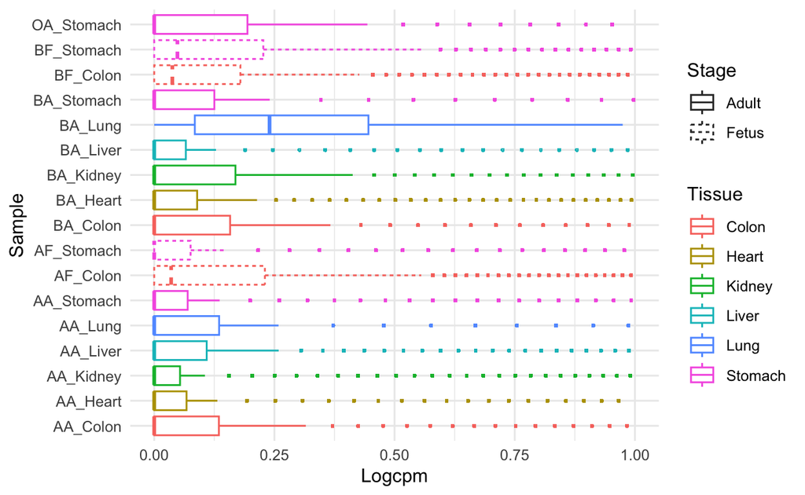

```r
gene_logcpm <- gene_counts %>%                              # a new dataframe with logcpm values
  select(Geneid) %>%
  bind_cols(logcpm) %>%                                     # bind the logcpm matrix to the geneids
  pivot_longer(-Geneid, names_to="Sample", values_to="Logcpm") %>%     # convert to tidy data
  separate(Sample,                                          # cleanup complex variables
           into = c("Source", "Stage", "Tissue"),
           sep = c(1,2),
           remove = F) %>%                                  # keep original variable
  mutate(Tissue = gsub("^_", "", Tissue),
         Stage = ifelse(Stage == "A", "Adult", "Fetus"))

View(head(gene_logcpm, 50))

# Plotting the distribution of gene-expression in each sample
gene_logcpm %>%
  ggplot(aes(x = Sample, y = Logcpm, color = Tissue, linetype = Stage)) +
  geom_boxplot(outlier.size = 0.2, outlier.shape = 0.2) +
  scale_y_continuous(limits = c(0, 1)) +
  coord_flip() +
  theme_minimal()
```

# Part 4: Visualizing tidy data w/ `ggplot`

## Basics of ggplot2

**Creating a plot w/ Grammar of Graphics**

> 1. Recap and continuation of **dplyr**
> 2. Basics of plotting data with **ggplot2**: `data`, `aes`, `geom`
> 3. Customization: Colors, labels, and legends

### Barplots & Histograms

- `ggplot`, `factor`, `aes`
- `geom_bar`, `geom_histogram`
- `facet_wrap`
- `scale_x_log10`, `labs`, `coord_flip`, `theme`, `theme_minimal`

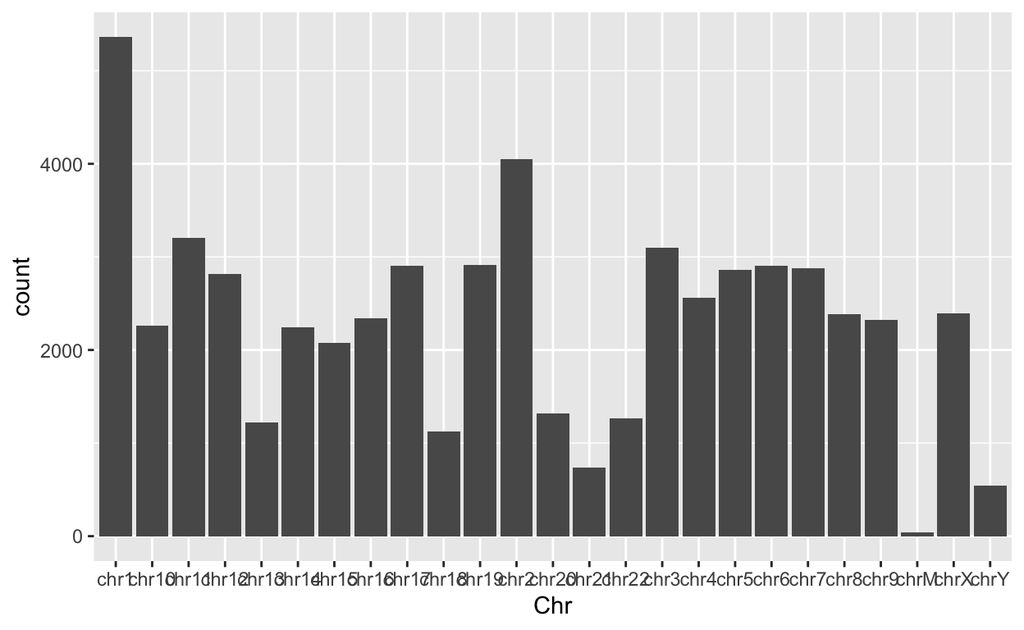

```r
gene_loc %>%                                                      # data
  ggplot(aes(x = Chr)) +                                          # aesthetics: what to plot?
  geom_bar()                                                      # geometry: how to plot?
```

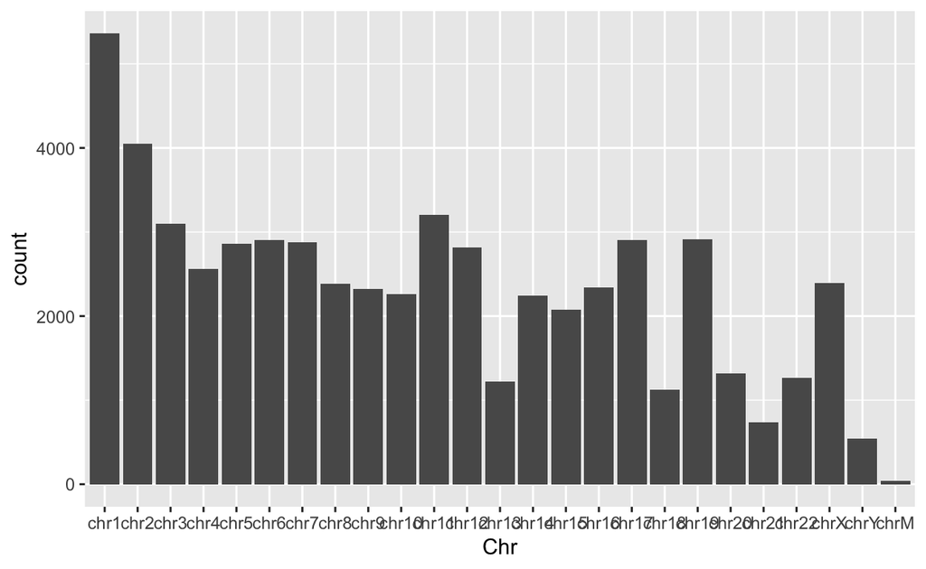

```r
gene_loc$Chr <- factor(gene_loc$Chr,
                       levels = paste("chr",
                                      c((1:22), "X", "Y", "M"),
                                      sep=""))

plot_chr_numgenes <- gene_loc %>%
  ggplot(aes(x = Chr)) +
  geom_bar()
plot_chr_numgenes
```

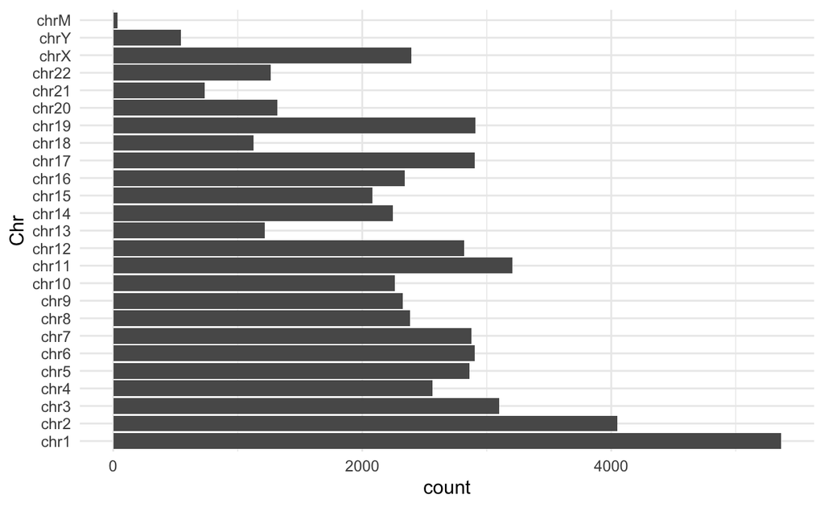

```r
plot_chr_numgenes +
  coord_flip() +
  theme_minimal()
```

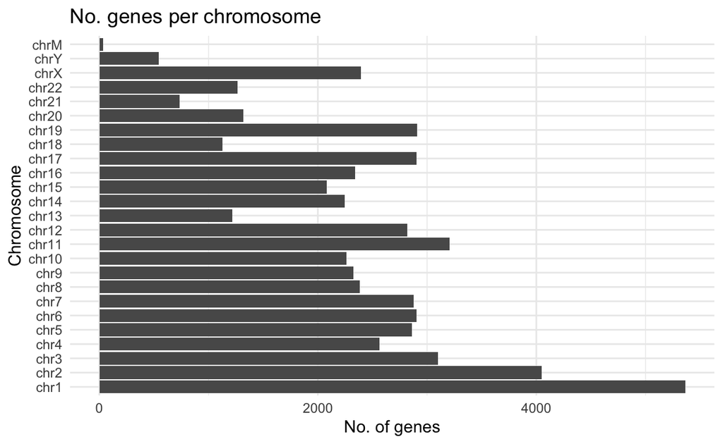

```r
plot_chr_numgenes +
  labs(title = "No. genes per chromosome",
       x = "Chromosome",
       y = "No. of genes") +
  theme_minimal() +
  coord_flip()
```

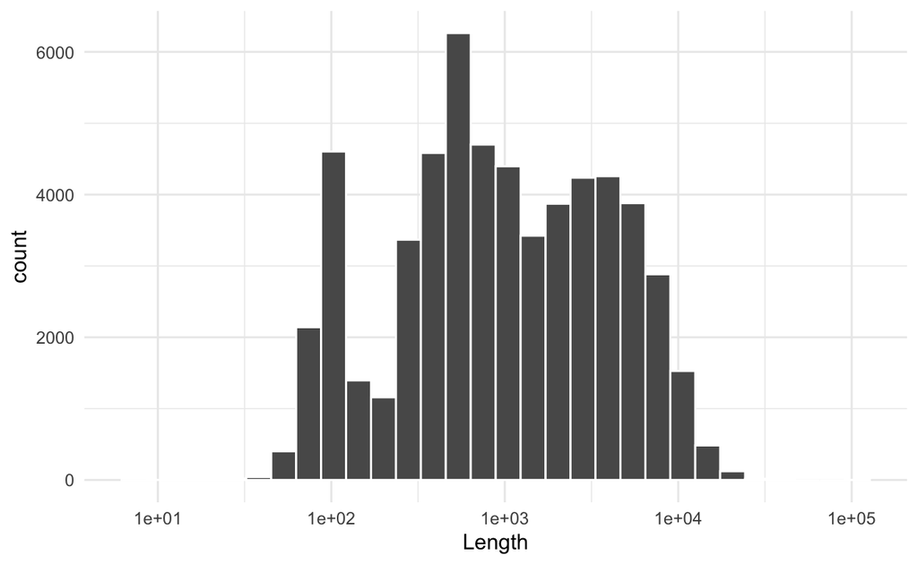

```r
gene_loc %>%
  ggplot(aes(x = Length)) +
  geom_histogram(color = "white") +
  scale_x_log10() +
  theme_minimal()
```

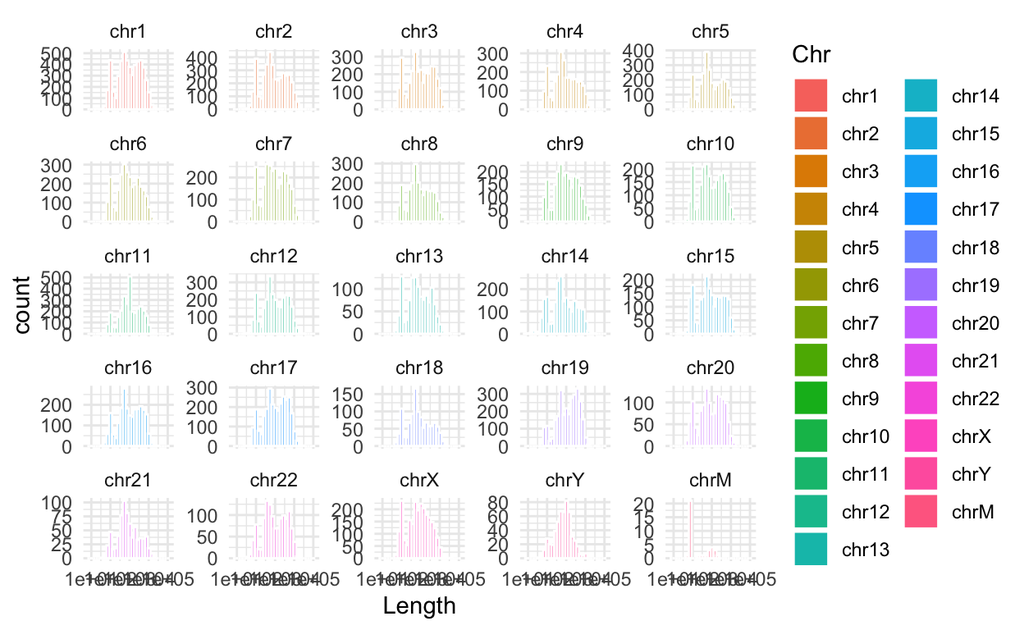

```r
plot_chr_genelength <- gene_loc %>%
  ggplot(aes(x = Length, fill = Chr)) +
  geom_histogram(color = "white") +
  scale_x_log10() +
  theme_minimal() +
  facet_wrap(~Chr, scales = "free_y")
plot_chr_genelength
```

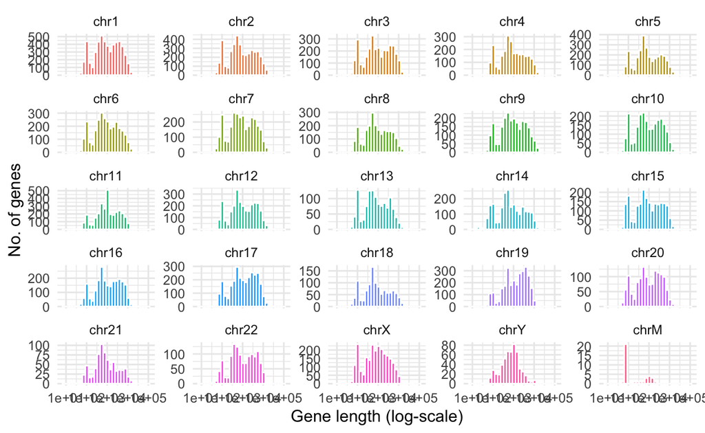

```r
plot_chr_genelength +
  theme(legend.position = "none") +
  labs(x = "Gene length (log-scale)",
       y = "No. of genes")
```

### Scatter plots

- `geom_point`
- `geom_abline`, `geom_vline`, `geom_hline`
- `geom_smooth`, `geom_text_repel`

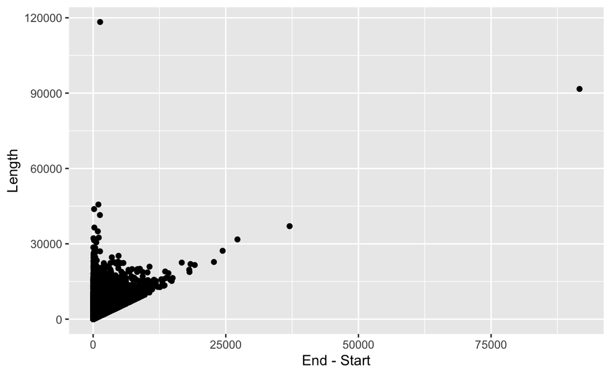

```r
gene_loc %>%
  ggplot(aes(x = End-Start, y = Length)) +
  geom_point()
```

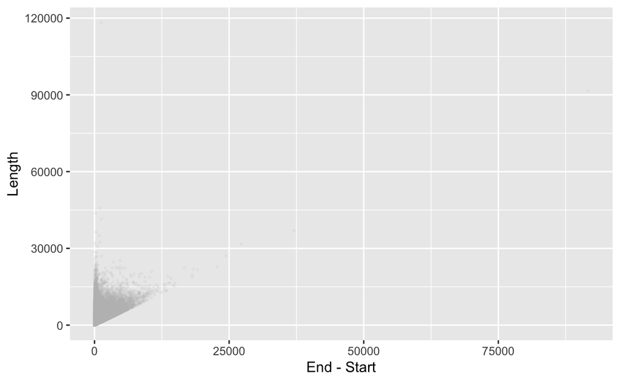

```r
plot_strend_length <- gene_loc %>%
  ggplot(aes(x = End-Start, y = Length)) +
  geom_point(alpha = 0.1, size = 0.5, color = "grey", fill = "grey")
plot_strend_length
```

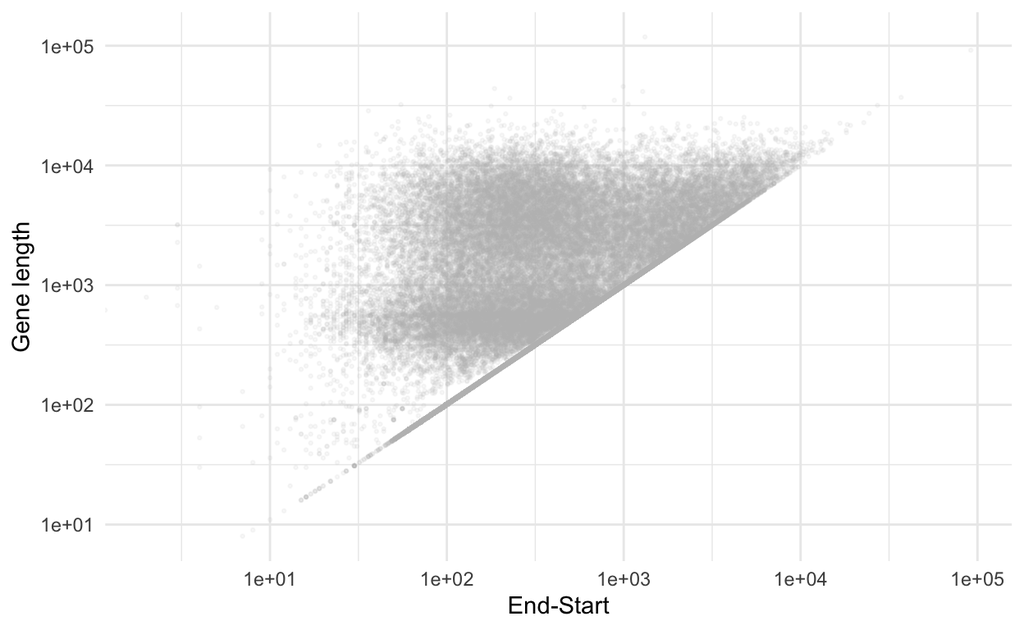

```r
plot_strend_length <- plot_strend_length +
  scale_x_log10("End-Start") +
  scale_y_log10("Gene length") +
  theme_minimal()
plot_strend_length
```

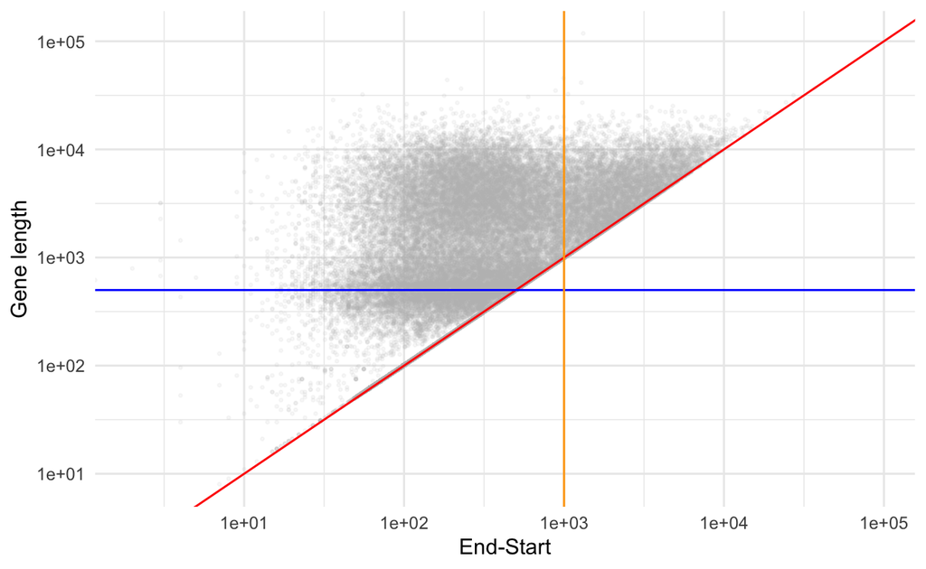

```r
plot_strend_length +
  geom_abline(intercept = 0, slope = 1, col = "red") +
  geom_hline(yintercept = 500, color = "blue") +
  geom_vline(xintercept = 1000, color = "orange")
```

```r
gene_loc %>%
  group_by(Chr) %>%
  summarize(meanLength = mean(Length), numGenes = n())
```

```
# A tibble: 25 × 3
   Chr   meanLength numGenes
   <fct>      <dbl>    <int>
 1 chr1       2258.     5363
 2 chr2       2304.     4047
 3 chr3       2382.     3101
 4 chr4       2109.     2563
 5 chr5       2188.     2859
 6 chr6       2124.     2905
 7 chr7       2164.     2876
 8 chr8       2036.     2386
 9 chr9       2123.     2323
10 chr10      2160.     2260
# ℹ 15 more rows
```

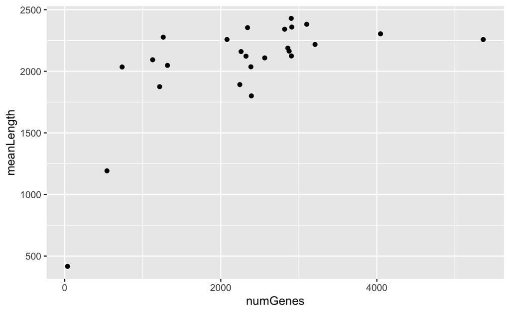

```r
gene_loc %>%
  group_by(Chr) %>%
  summarize(meanLength = mean(Length), numGenes = n()) %>%
  ggplot(aes(x = numGenes, y = meanLength)) +
  geom_point()
```

[output not shown]

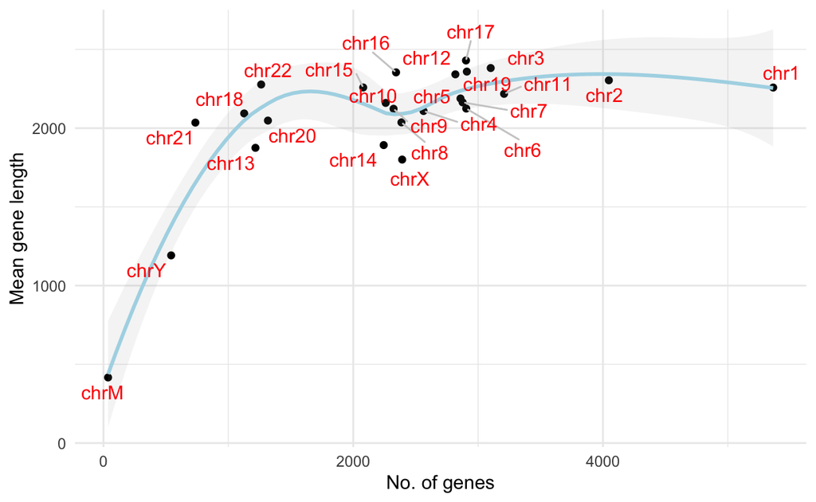

```r
# install.packages("ggrepel", dependencies=T)
library(ggrepel)
gene_loc %>%
  group_by(Chr) %>%
  summarize(meanLength = mean(Length), numGenes = n()) %>%
  ggplot(aes(x = numGenes, y = meanLength)) +
  geom_point() +
  geom_smooth(color = "lightblue", alpha = 0.1) +
  labs(x = "No. of genes", y = "Mean gene length") +
  geom_text_repel(aes(label = Chr), color="red", segment.color="grey80") +
  theme_minimal()
```

### Boxplots & Violin plots

- `geom_boxplot`, `geom_violin`
- `scale_y_continuous`

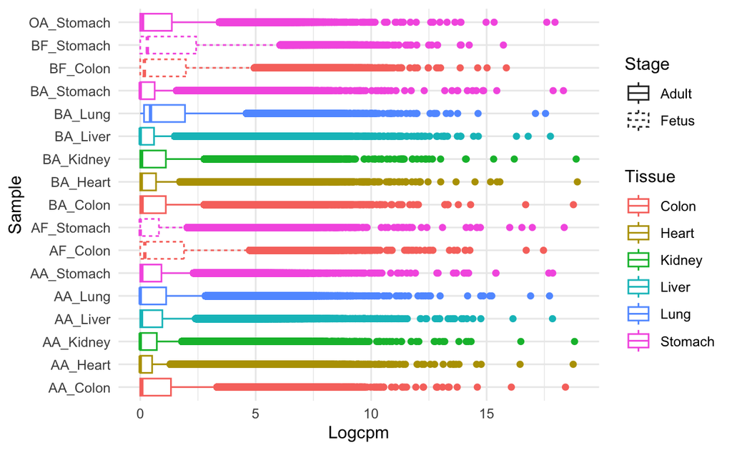

```r
gene_logcpm %>%
  ggplot(aes(x = Sample, y = Logcpm, color = Tissue, linetype = Stage)) +
  geom_boxplot() +
  coord_flip() +
  theme_minimal()
```

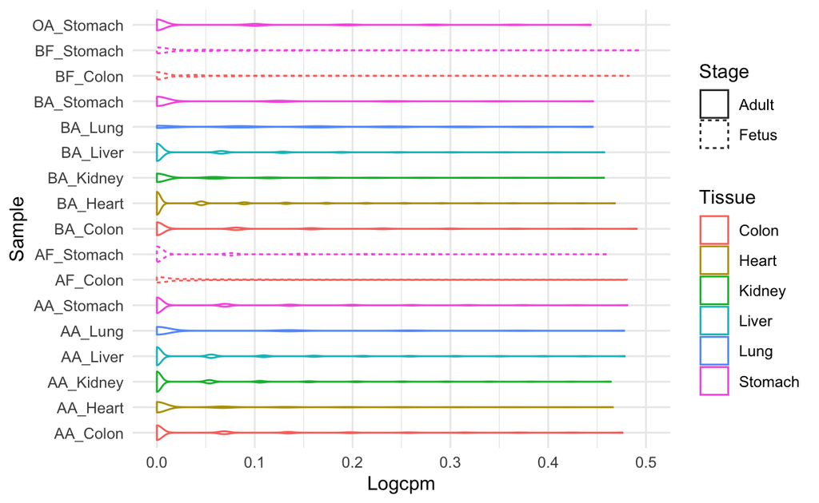

```r
gene_logcpm %>%
  ggplot(aes(x = Sample, y = Logcpm, color = Tissue, linetype = Stage)) +
  geom_violin() +
  scale_y_continuous(limits = c(0, 0.5)) +
  coord_flip() +
  theme_minimal()
```

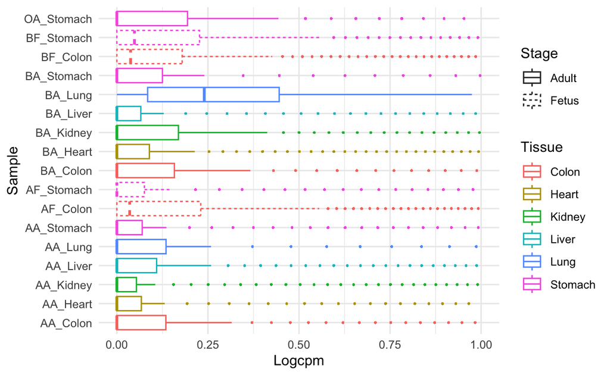

```r
# Plotting the distribution of gene-expression in each sample
plot_sample_bxp <- gene_logcpm %>%
  ggplot(aes(x = Sample, y = Logcpm, color = Tissue, linetype = Stage)) +
  geom_boxplot(outlier.size = 0.2, outlier.alpha = 0.2) +
  scale_y_continuous(limits = c(0, 1)) +
  coord_flip() +
  theme_minimal()
plot_sample_bxp
```

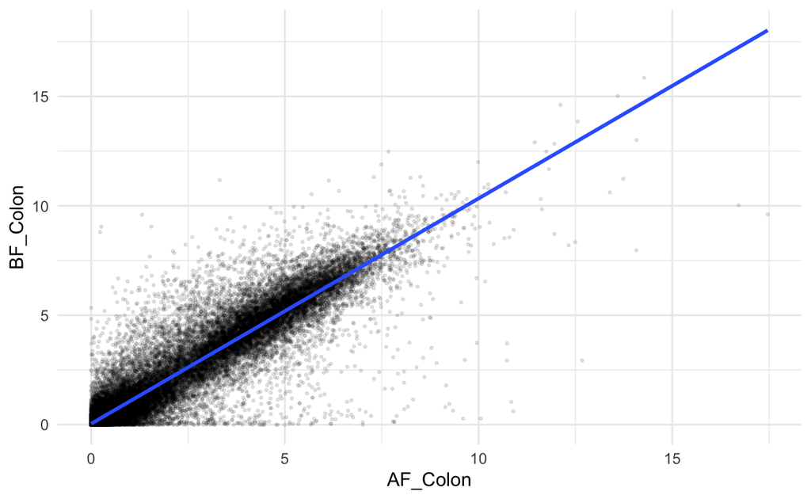

```r
# Plotting scatterplot of 2 sets of samples
plot_ffcolon_scatter <- gene_logcpm %>%
  filter(Sample == "AF_Colon" | Sample == "BF_Colon") %>%
  select(Geneid, Sample, Logcpm) %>%
  pivot_wider(names_from = Sample, values_from = Logcpm) %>%
  ggplot(aes(x = AF_Colon, y = BF_Colon)) +
  geom_point(alpha = 0.1, size = 0.5) +
  geom_smooth(method=lm) +
  theme_minimal()
plot_ffcolon_scatter
```

### Some data sleuthing

```r
# Finding genes with high variance across samples
num_totgenes <- gene_logcpm %>%
  distinct(Geneid) %>%
  nrow()

highvar_genes <- gene_logcpm %>%
  group_by(Geneid) %>%
  summarize(iqr = IQR(Logcpm)) %>%
  top_n((ceiling(num_totgenes*0.05)), iqr) %>%
  pull(Geneid)

length(highvar_genes)
```

```
[1] 2891
```

```r
# Plotting expression of high-var Y chr genes across samples
chry_highvar_genes <- gene_loc %>%
  filter(Chr == "chrY" & Geneid %in% highvar_genes) %>%
  pull(Geneid)

gene_logcpm %>%
  filter(Geneid %in% chry_highvar_genes)
```

```
# A tibble: 238 × 6
   Geneid          Sample     Source Stage Tissue  Logcpm
   <chr>           <chr>      <chr>  <chr> <chr>    <dbl>
 1 ENSG00000129824 AA_Colon   A      Adult Colon   6.12
 2 ENSG00000129824 AA_Heart   A      Adult Heart   0
 3 ENSG00000129824 AA_Kidney  A      Adult Kidney  0.106
 4 ENSG00000129824 AA_Liver   A      Adult Liver   1.75
 5 ENSG00000129824 AA_Lung    A      Adult Lung    0
 6 ENSG00000129824 AA_Stomach A      Adult Stomach 0
 7 ENSG00000129824 AF_Colon   A      Fetus Colon   0.0352
 8 ENSG00000129824 AF_Stomach A      Fetus Stomach 4.51
 9 ENSG00000129824 BA_Colon   B      Adult Colon   6.05
10 ENSG00000129824 BA_Heart   B      Adult Heart   4.81
# ℹ 228 more rows
```

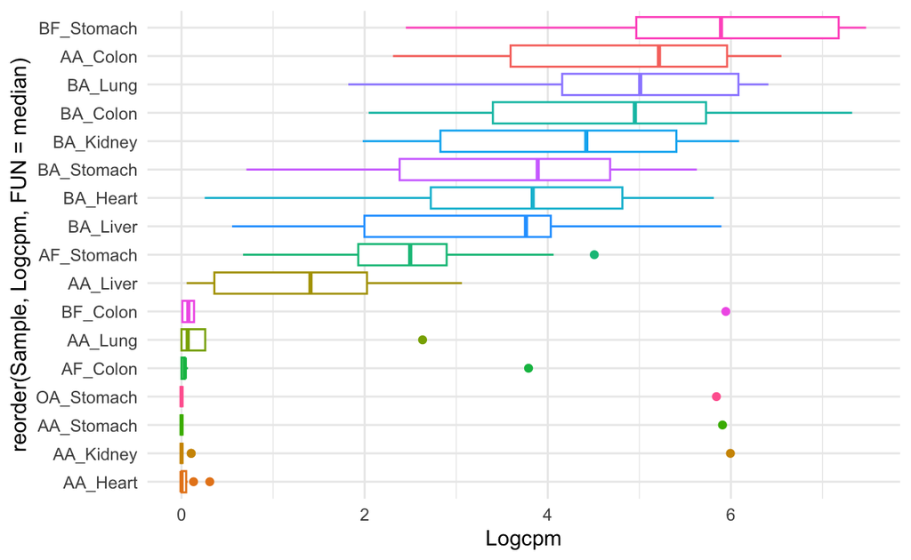

```r
plot_chry_highvar_boxplot <- gene_logcpm %>%
  filter(Geneid %in% chry_highvar_genes) %>%
  ggplot(aes(x = reorder(Sample, Logcpm, FUN = median),
             y = Logcpm,
             color = Sample)) +
  geom_boxplot() +
  coord_flip() +
  theme_minimal() +
  theme(legend.position = "none")
plot_chry_highvar_boxplot
```

# Part 5: Export & Wrap-up w/ `RMarkdown`

## Saving your plots

### ggsave

**Save a ggplot (or other grid object) with sensible defaults**

```r
library(tidyverse)
# Save your file name
plot1 <- "chr_highvar.png"

# Save your absolute/relative path
my_full_path <- here("transcriptomics")

# To save as a tab-delimited text file ...
ggsave(filename=plot1,
       plot=plot_chry_highvar_boxplot,
       device="png",
       path=my_full_path,
       dpi=600)
```

## Saving your data files

### write_delim

**Write a dataframe to a delimited file**

```r
library(tidyverse)
# Save your file name
filename <- "my_new_data.txt"

# Save your absolute/relative path
my_full_path <- here("data")

# To save as a tab-delimited text file ...
write_tsv(x=my_newly_formatted_data, # your final reformatted dataset
          path=paste(my_full_path, filename, "/"), # Absolute path recommended.
          # However, you can directly use 'filename' here
          # if you are saving the file in the same directory
          # as your code.
          col_names=T) # if you want the column names to be
# saved in the first row, recommended

# Alternatively, you could save it as a comma-separated text file
write_csv(x=my_newly_formatted_data,
          path=my_path,
          col_names=T)
# Or save it with any other delimiter
# choose wisely, pick a delim that's not part of your dataframe
write_delim(x=my_newly_formatted_data,
            path=my_path,
            col_names=T,
            delim="---")
```

## *What you learnt today!*

| Option | Description |
| --- | --- |
| **Part 1** | **Getting Started** |
| `install.packages` | Download and install packages from CRAN-like repositories or from local files |
| `library` | Library and require load and attach add-on packages |
| `package::function` | To run a function w/o loading the package |
| *Import* | `tidyverse` > `readr` & `readxl` |
| `read_delim` | Read a delimited file (incl csv, tsv) into a tibble |
| `read_csv, read_tsv` | read_csv() and read_tsv() are special cases of the general read_delim() |
| `read_excel` | Read xls and xlsx files |
| `here` | Part of `here` package. To set paths relative to your current project directory |
| *Data snapshot* |  |
| `str` | Compactly Display the Structure of an Arbitrary R Object |
| `head` | Return the First or Last Part of an Object |
| `glimpse` | Get a glimpse of your data |
| `View` | Invoke a Data Viewer (pop-up, requires XQuartz/X11) |
| `kable` | Create tables in LaTeX, HTML, Markdown and reStructuredText |
| `paged_table` | Create a table in HTML with support for paging rows and columns |
| **Part 2** | `tidyverse` > `tidyr` |
| `pivot_longer` | Gather Columns Into Key-Value Pairs (COLS -> ROWS) |
| `pivot_wider` | Spread a key-value pair across multiple columns |
| `separate` | Separate one column into multiple column |
| `unite` | Unite multiple columns into one |
| **Part 3** | `tidyverse` > `dplyr` |
| `filter` | Return rows with matching conditions |
| `select` | Select/rename variables by name |
| `mutate` | Add new variables |
| `transmute` | Add new variables & drops existing variables |
| `distinct` | Get unique entries |
| `arrange` | Arrange rows by variables |
| `summarise` | Reduces multiple values down to a single value |
| `group_by` | Group by one or more variables |
| `join` | Join two dataframes together: `left_join`, `right_join`, `inner_join` |
| `bind` | Efficiently bind multiple dataframes by row and column: `bind_rows`, `bind_cols` |
| `setops` | Set operations: `intersect`, `union`, `setdiff`, `setequal` |
| **Part 4** | `tidyverse` > `ggplot` |
| `ggplot` | Create a new ggplot |
| *Aesthetics* |  |
| `aes` | Specify details on what to plot |
| `factor` | Specify a variable to be ordered & categorical |
| `facet_wrap` | Split into multiple sub-plots based on a categorical variable |
| *Geometries* |  |
| `geom_bar` | Create a barplot |
| `geom_histogram` | Create a histogram |
| `geom_point` | Create a scatter plot |
| `geom_boxplot` | Create a boxplot |
| `geom_violin` | Create a violin plot |
| `geom_abline, geom_hline, geom_vline` | Add slanted, horizontal, or vertical lines |
| `geom_smooth` | Add a smooth curve that fits the data points |
| *Plot customization* |  |
| `theme, theme_minimal, theme_bw` | Adjust themes to minimal, black/white, etc |
| `scale_x_log10` | Change x/y axes to log scale |
| `scale_y_continuous` | Change x/y axes to continuous & set limits |
| `coord_flip` | Flip x & y coordinates |
| `labs` | Specify axes labels and plot titles |
| **Part 5** | **Export & Wrap-up** |
| *Export* | `tidyverse` > `readr` |
| `ggsave` | Save a ggplot (or other grid object) with sensible defaults |
| `write_delim` | Write a dataframe to a delimited file |
| `write_tsv` | write_delim customized for tab-separated values |
| `write_csv` | write_delim customized for comma-separated values |

## Credits

[Arjun Krishnan](https://thekrishnanlab.org) and [I](https://jravilab.github.io) co-developed the content for this workshop.

### Acknowledgements

- [Krishnan Lab](https://thekrishnanlab.org) | [JRaviLab](https://jravilab.github.io)
- [R-Ladies East Lansing](https://rladies-eastlansing.github.io)
- Hosts: [R-Ladies Chennai](https://meetup.com/rladies-chennai) | [R-Ladies Bangalore](https://meetup.com/rladies-bangalore) | [R-Ladies Tunis](https://meetup.com/rladies-tunis) | [MSU](https://msu.edu) | [ISCB Academy](https://www.iscb.org/iscbacademy)

### Contact

- Webpage: jravilab.github.io | thekrishnanlab.org
- Email: janani@msu.edu | arjun@msu.edu
- Twitter: [@janani137](https://twitter.com/janani137) | [@compbiologist](https://twitter.com/compbiologist)
- GitHub: [@jananiravi](https://github.com/jananiravi) | [@arjunkrish](https://github.com/arjunkrish)

Additional resources

- You can access all relevant material pertaining to this workshop [here](https://github.com/rladies-aurora/202503-RIntro-DataWrangling-Transcriptomics).
- Other related [R-Ladies Aurora workshops](https://github.com/rladies-aurora) & useful cheatsheets.
- [Computational biology gists](https://github.com/jananiravi/compbio-gists)
- [Data-to-viz.com](https://www.data-to-viz.com) and [R Graph Gallery](https://r-graph-gallery.com)

### Some awesome open-source books

- Hands-On Programming with R: Grolemund #HOPR https://rstudio-education.github.io/hopr
- R for Data Science: Wickham & Grolemund #R4DS https://r4ds.had.co.nz
- R Programming for Data Science: Peng https://leanpub.com/rprogramming
- Learning Statistics with R: Navarro https://learningstatisticswithr.com/book

### Other helpful links

- #TidyTuesday challenges | On [GitHub](https://github.com/rfordatascience/tidytuesday), [Twitter](https://twitter.com/search?q=%23TidyTuesday&src=typeahead_click).
- gganimate: thomasp85/gganimate
- tidyexplain: gadenbuie/tidyexplain
- Distill (theme for RMarkdown): https://rstudio.github.io/distill
- Google & [StackOverflow](https://stackoverflow.com) are your best friends!